# CEspitia_AssignFinal

Cesar Espitia

5/13/2018

## Final Data 605 Spring 2018

Your final is due by the end of day on 5/20/2018 You should post your solutions to your GitHub account or RPubs. You are also expected to make a short presentation via YouTube and post that recording to the board. This project will show off your ability to understand the elements of the class.

You are to register for Kaggle.com (free) and compete in the House Prices: Advanced Regression Techniques competition. https://www.kaggle.com/c/house-prices-advanced-regression-techniques . I want you to do the following. * Pick one of the quantitative independent variables from the training data set (train.csv) , and define that variable as X. Make sure this variable is skewed to the right! * Pick the dependent variable and define it as Y.

### Data Exploration

The data is loaded and the summary is being obtained for all variables (categorial or continuous). In this case, I will only consider continouous variables for this anlaysis.

```r
train = read.csv("train.csv")
head(summary(train))
```

```
##        Id           MSSubClass       MSZoning     LotFrontage
##  Min.   :   1.0   Min.   : 20.0   C (all):  10   Min.   : 21.00
##  1st Qu.: 365.8   1st Qu.: 20.0   FV     :  65   1st Qu.: 59.00
##  Median : 730.5   Median : 50.0   RH     :  16   Median : 69.00
##  Mean   : 730.5   Mean   : 56.9   RL     :1151   Mean   : 70.05
##  3rd Qu.:1095.2   3rd Qu.: 70.0   RM     : 218   3rd Qu.: 80.00
##  Max.   :1460.0   Max.   :190.0                  Max.   :313.00
##     LotArea        Street      Alley      LotShape  LandContour
##  Min.   :  1300   Grvl:   6   Grvl:  50   IR1:484   Bnk:  63
##  1st Qu.:  7554   Pave:1454   Pave:  41   IR2: 41   HLS:  50
##  Median :  9478               NA's:1369   IR3: 10   Low:  36
##  Mean   : 10517                           Reg:925   Lvl:1311
##  3rd Qu.: 11602
##  Max.   :215245
##   Utilities      LotConfig    LandSlope   Neighborhood   Condition1
##  AllPub:1459   Corner : 263   Gtl:1382   NAmes  :225   Norm   :1260
##  NoSeWa:   1   CulDSac:  94   Mod:  65   CollgCr:150   Feedr  :  81
##                FR2    :  47   Sev:  13   OldTown:113   Artery :  48
##                FR3    :   4              Edwards:100   RRAn   :  26
##                Inside :1052              Somerst: 86   PosN   :  19
##                                          Gilbert: 79   RRAe   :  11
##    Condition2     BldgType      HouseStyle   OverallQual
##  Norm   :1445   1Fam  :1220   1Story :726   Min.   : 1.000
##  Feedr  :   6   2fmCon:  31   2Story :445   1st Qu.: 5.000
##  Artery :   2   Duplex:  52   1.5Fin :154   Median : 6.000
##  PosN   :   2   Twnhs :  43   SLvl   : 65   Mean   : 6.099
##  RRNn   :   2   TwnhsE: 114   SFoyer : 37   3rd Qu.: 7.000
##  PosA   :   1                 1.5Unf : 14   Max.   :10.000
##   OverallCond      YearBuilt     YearRemodAdd    RoofStyle
##  Min.   :1.000   Min.   :1872   Min.   :1950   Flat   :  13
##  1st Qu.:5.000   1st Qu.:1954   1st Qu.:1967   Gable  :1141
##  Median :5.000   Median :1973   Median :1994   Gambrel:  11
##  Mean   :5.575   Mean   :1971   Mean   :1985   Hip    : 286
##  3rd Qu.:6.000   3rd Qu.:2000   3rd Qu.:2004   Mansard:   7
##  Max.   :9.000   Max.   :2010   Max.   :2010   Shed   :   2
##     RoofMatl     Exterior1st   Exterior2nd    MasVnrType    MasVnrArea
##  CompShg:1434   VinylSd:515   VinylSd:504   BrkCmn : 15   Min.   :   0.0
##  Tar&Grv:  11   HdBoard:222   MetalSd:214   BrkFace:445   1st Qu.:   0.0
##  WdShngl:   6   MetalSd:220   HdBoard:207   None   :864   Median :   0.0
##  WdShake:   5   Wd Sdng:206   Wd Sdng:197   Stone  :128   Mean   : 103.7
```

[output cut: 71 more lines]

```
##  Max.   :508.00   Max.   :480.00   Max.   :738.000
##    Fence      MiscFeature    MiscVal             MoSold
##  GdPrv:  59   Gar2:   2   Min.   :    0.00   Min.   : 1.000
##  GdWo :  54   Othr:   2   1st Qu.:    0.00   1st Qu.: 5.000
##  MnPrv: 157   Shed:  49   Median :    0.00   Median : 6.000
##  MnWw :  11   TenC:   1   Mean   :   43.49   Mean   : 6.322
##  NA's :1179   NA's:1406   3rd Qu.:    0.00   3rd Qu.: 8.000
##                           Max.   :15500.00   Max.   :12.000
##      YrSold        SaleType    SaleCondition    SalePrice
##  Min.   :2006   WD     :1267   Abnorml: 101   Min.   : 34900
##  1st Qu.:2007   New    : 122   AdjLand:   4   1st Qu.:129975
##  Median :2008   COD    :  43   Alloca :  12   Median :163000
##  Mean   :2008   ConLD  :   9   Family :  20   Mean   :180921
##  3rd Qu.:2009   ConLI  :   5   Normal :1198   3rd Qu.:214000
##  Max.   :2010   ConLw  :   5   Partial: 125   Max.   :755000
```

```r
#fill NAs with 0.
train[is.na(train)] <- 0
```

[output not shown]

```r
summary(train$BsmtFinSF1)
```

```
##    Min. 1st Qu.  Median    Mean 3rd Qu.    Max.
##     0.0     0.0   383.5   443.6   712.2  5644.0
```

```r
summary(train$BsmtFinSF2)
```

```
##    Min. 1st Qu.  Median    Mean 3rd Qu.    Max.
##    0.00    0.00    0.00   46.55    0.00 1474.00
```

```r
train$BsmtFinSF12 = train$BsmtFinSF1+train$BsmtFinSF2


#import test data for submission
test = read.csv("test.csv")

#fill NAs with 0.
test[is.na(test)] <- 0
```

[output not shown]

[output cut: 10 more lines]

[output not shown]

```r
#function to get mode of a variable.
getmode <- function(v) {
  uniqv <- unique(v)
  uniqv[which.max(tabulate(match(v, uniqv)))]
}

#test for skewneess
summary(train$BsmtFinSF12)[4]>summary(train$BsmtFinSF12)[3]
```

```
## Mean
## TRUE
```

```r
summary(train$BsmtFinSF12)[3]>getmode(train$BsmtFinSF12)
```

```
## Median
##   TRUE
```

```r
skewness(train$BsmtFinSF12)
```

```
## [1] 1.403074
```

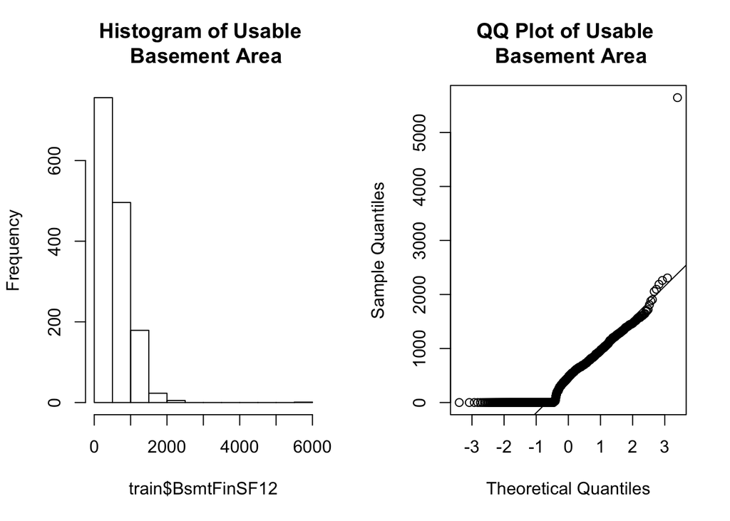

```r
#visual of skewness
par(mfrow=c(1,2))
hist(train$BsmtFinSF12, main ='Histogram of Usable \n Basement Area')

qqnorm(train$BsmtFinSF12, main ='QQ Plot of Usable \n Basement Area')
qqline(train$BsmtFinSF12)
```

In addition, the data was selected because of its skewness which in this case is mean > median > mode which is 490.2 > 465 > 0. The data has a lower bound of 0, as an area can only be greater than or equal to 0 in livable space. The histogram and the qqplot also visually confirm this information.

The dependent variable for this analysis will be the Sale Price of the home, the function will have the form of $f(x) = SalePrice = m*BsmtFinSF12+b$ where BsmtFinSF12 is the sum of column BsmtFinSF1 and BsmtFinSF2 as noted above.

### Probability.

Calculate as a minimum the below probabilities a through c. Assume the small letter “x” is estimated as the 1st quartile of the X variable, and the small letter “y” is estimated as the 1st quartile of the Y variable. Interpret the meaning of all probabilities. In addition, make a table of counts as shown below.

To populate the table of probabilities for the 1st quartile for x and 2nd quartile for y, I will be using the quantile function in r.

1. P(X>x|Y>y)

```r
xq1 <- quantile(train$BsmtFinSF12, 0.25)
yq2 <- quantile(train$SalePrice, 0.5)

rowcount <- dim(train)[1]
upperxq1yq2 <- filter(train, train$SalePrice > yq2 & train$BsmtFinSF12 > xq1) %>% count()
upperyq2 <- filter(train, train$SalePrice > yq2) %>% count()

(upperxq1yq2/rowcount) / (upperyq2/rowcount)
```

```
##          n
## 1 0.706044
```

```r
#insert into matrix table
d22<- filter(train, train$SalePrice > yq2 & train$BsmtFinSF12 > xq1) %>% count()
```

The value for P(X>x|Y>y) is 0.7060.

2. P(X>x,Y>y)

```r
upperxq1yq2 <- filter(train, train$SalePrice > yq2 & train$BsmtFinSF12 > xq1) %>% count()
upperyq2 <- filter(train, train$SalePrice > yq2) %>% count()

(upperxq1yq2/rowcount) * (upperyq2/rowcount)
```

```
##           n
## 1 0.1755451
```

The value for P(X>x,Y>y) is 0.1755.

```r
upperyq2xq1 <- filter(train, train$SalePrice > yq2 & train$BsmtFinSF12 < xq1) %>% count()
upperyq2 <- filter(train, train$SalePrice > yq2) %>% count()

(upperyq2xq1/rowcount)/(upperyq2/rowcount)
```

```
##   n
## 1 0
```

```r
#Insert into matrix table
d21<- filter(train, train$SalePrice > yq2 & train$BsmtFinSF12 < xq1) %>% count()
```

Does splitting the training data in this fashion make them independent?

```r
#Insert into matrix table.  Fill in other items including row and column sums.
d23 <- filter(train, train$SalePrice > yq2) %>% count()
d13 <- dim(train)[1]-d23
d32 <- filter(train, train$BsmtFinSF12 > xq1) %>% count()
d31 <- dim(train)[1]-d32
d11 <- d31-d21
d12 <- d32-d22
d33 <- dim(train)[1]

#prepare table
tab <- matrix(c(d11,d21,d31,d12,d22,d32,d13,d23,d33), 3, 3, byrow = T)

print(tab)
```

```
##      [,1] [,2] [,3]
## [1,] 467  0    467
## [2,] 479  514  993
## [3,] 732  728  1460
```

```r
PA <- d32/d33
PB <- d23/d33
PA*PB
```

```
##           n
## 1 0.3391368
```

#### Check mathematically, and then evaluate by running a Chi Square test for association.

```r
chimat<-rbind(c(467,0),c(479,514))
chisq.test(chimat,correct=TRUE)
```

```
##
##  Pearson's Chi-squared test with Yates' continuity correction
##
## data:  chimat
## X-squared = 370.81, df = 1, p-value < 2.2e-16
```

```r
#check variables also
chisq.test(train$TotalBsmtSF, train$SalePrice, correct=FALSE)
```

```
##
##  Pearson's Chi-squared test
##
## data:  train$TotalBsmtSF and train$SalePrice
## X-squared = 509710, df = 476640, p-value < 2.2e-16
```

### Descriptive and Inferential Statistics.

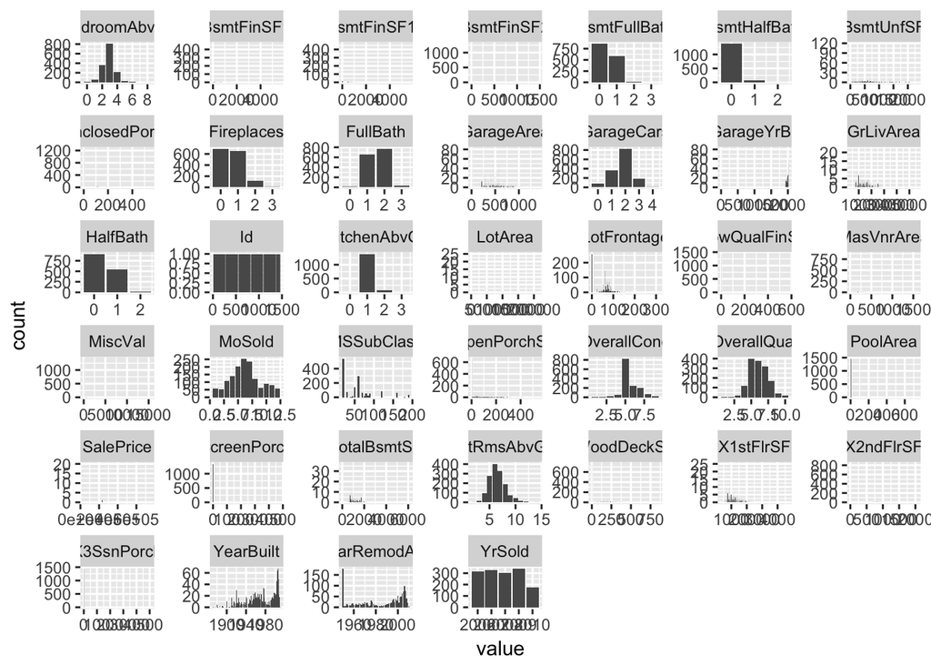

```r
library("dplyr")
library(purrr)
library(tidyr)
library(ggplot2)
library(corrplot)
ntrain<-select_if(train, is.numeric)
ntrain %>%
  keep(is.numeric) %>%                     # Keep only numeric columns
  gather() %>%                             # Convert to key-value pairs
  ggplot(aes(value)) +                     # Plot the values
    facet_wrap(~ key, scales = "free") +   # In separate panels
    geom_bar()                         # as density
```

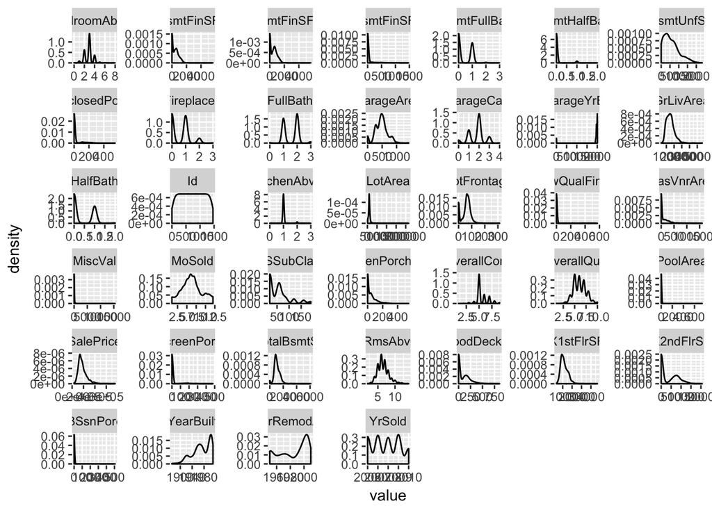

```r
ntrain %>%
  keep(is.numeric) %>%                     # Keep only numeric columns
  gather() %>%                             # Convert to key-value pairs
  ggplot(aes(value)) +                     # Plot the values
    facet_wrap(~ key, scales = "free") +   # In separate panels
    geom_density()                         # as density
```

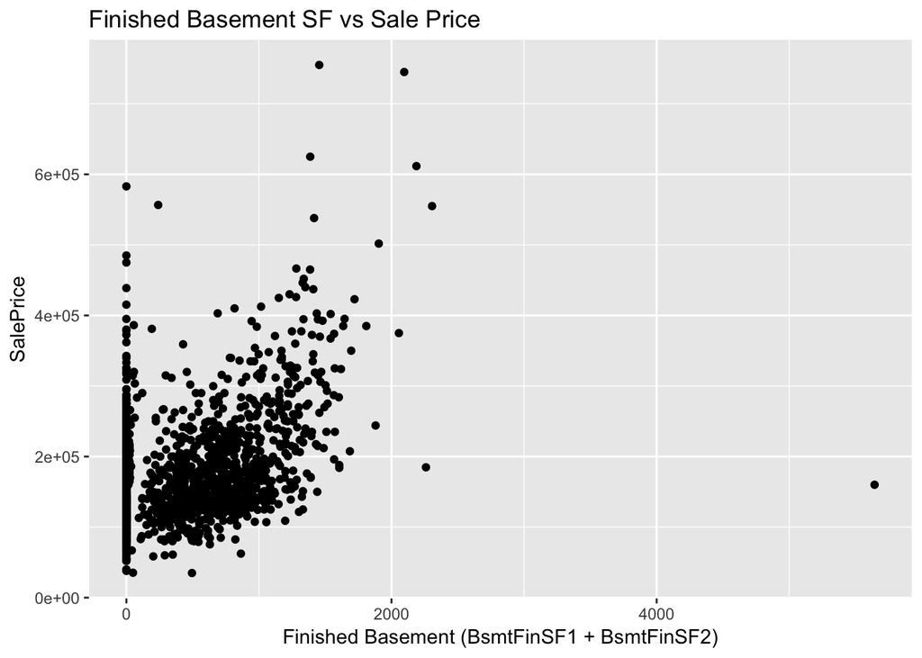

```r
subset <- select(train, TotalBsmtSF, TotRmsAbvGrd, LotArea, SalePrice)

subcor <- cor(subset)

par(mfrow=c(1,2))
ggplot(train, aes(x=BsmtFinSF12,y=SalePrice)) + geom_point() + ggtitle("Finished Basement SF vs Sale Price") + xlab("Finished Basement (BsmtFinSF1 + BsmtFinSF2)")
```

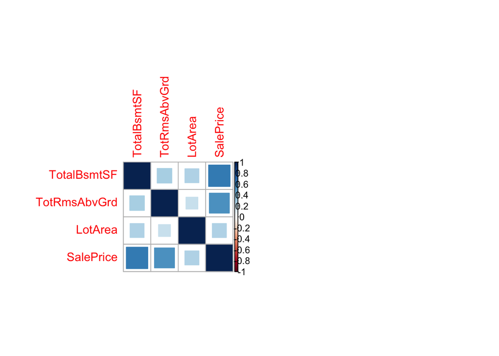

```r
corrplot(subcor, method="square")
```

The best correlation is TotalBsmtSF and SalePrice according to the information from the correlation plot.

```r
cor.test(train$TotalBsmtSF, train$SalePrice, method = "pearson" , conf.level = 0.92)
```

```
##
##  Pearson's product-moment correlation
##
## data:  train$TotalBsmtSF and train$SalePrice
## t = 29.671, df = 1458, p-value < 2.2e-16
## alternative hypothesis: true correlation is not equal to 0
## 92 percent confidence interval:
##  0.5841762 0.6413763
## sample estimates:
##       cor
## 0.6135806
```

```r
cor.test(train$TotRmsAbvGrd, train$SalePrice, method = "pearson" , conf.level = 0.92)
```

```
##
##  Pearson's product-moment correlation
##
## data:  train$TotRmsAbvGrd and train$SalePrice
## t = 24.099, df = 1458, p-value < 2.2e-16
## alternative hypothesis: true correlation is not equal to 0
## 92 percent confidence interval:
##  0.5001246 0.5657172
## sample estimates:
##       cor
## 0.5337232
```

```r
cor.test(train$LotArea, train$SalePrice, method = "pearson" , conf.level = 0.92)
```

```
##
##  Pearson's product-moment correlation
##
## data:  train$LotArea and train$SalePrice
## t = 10.445, df = 1458, p-value < 2.2e-16
## alternative hypothesis: true correlation is not equal to 0
## 92 percent confidence interval:
##  0.2206794 0.3059759
## sample estimates:
##       cor
## 0.2638434
```

This indicates that there is correlation as the p-value is < 0.5 for all three selected variables. In all cases, the correlation values also fall within the 92 CI.

```r
cor.test(train$TotalBsmtSF, train$SalePrice, method = "pearson" , conf.level = 0.9733)
```

```
##
##  Pearson's product-moment correlation
##
## data:  train$TotalBsmtSF and train$SalePrice
## t = 29.671, df = 1458, p-value < 2.2e-16
## alternative hypothesis: true correlation is not equal to 0
## 97.33 percent confidence interval:
##  0.5760909 0.6484941
## sample estimates:
##       cor
## 0.6135806
```

```r
cor.test(train$TotRmsAbvGrd, train$SalePrice, method = "pearson" , conf.level = 0.9733)
```

```
##
##  Pearson's product-moment correlation
##
## data:  train$TotRmsAbvGrd and train$SalePrice
## t = 24.099, df = 1458, p-value < 2.2e-16
## alternative hypothesis: true correlation is not equal to 0
## 97.33 percent confidence interval:
##  0.4909302 0.5739468
## sample estimates:
##       cor
## 0.5337232
```

```r
cor.test(train$LotArea, train$SalePrice, method = "pearson" , conf.level = 0.9733)
```

```
##
##  Pearson's product-moment correlation
##
## data:  train$LotArea and train$SalePrice
## t = 10.445, df = 1458, p-value < 2.2e-16
## alternative hypothesis: true correlation is not equal to 0
## 97.33 percent confidence interval:
##  0.2090551 0.3169804
## sample estimates:
##       cor
## 0.2638434
```

### Linear Algebra and Correlation.

Invert your 3 x 3 correlation matrix from above. (This is known as the precision matrix and contains variance inflation factors on the diagonal.) Multiply the correlation matrix by the precision matrix, and then multiply the precision matrix by the correlation matrix. Conduct LU decomposition on the matrix.

The following items generate the inverted matrix from the correlation matrix.

```r
print(subcor)
```

```
##              TotalBsmtSF TotRmsAbvGrd   LotArea SalePrice
## TotalBsmtSF    1.0000000    0.2855726 0.2608331 0.6135806
## TotRmsAbvGrd   0.2855726    1.0000000 0.1900148 0.5337232
## LotArea        0.2608331    0.1900148 1.0000000 0.2638434
## SalePrice      0.6135806    0.5337232 0.2638434 1.0000000
```

```r
inv<-solve(subcor)
print(inv)
```

```
##              TotalBsmtSF TotRmsAbvGrd     LotArea  SalePrice
## TotalBsmtSF    1.6396732   0.10848043 -0.18011064 -1.0164491
## TotRmsAbvGrd   0.1084804   1.41061034 -0.08612454 -0.7967135
## LotArea       -0.1801106  -0.08612454  1.09853013 -0.1333608
## SalePrice     -1.0164491  -0.79671350 -0.13336082  2.0840842
```

```r
round(subcor %*% inv)
```

```
##              TotalBsmtSF TotRmsAbvGrd LotArea SalePrice
## TotalBsmtSF            1            0       0         0
## TotRmsAbvGrd           0            1       0         0
## LotArea                0            0       1         0
## SalePrice              0            0       0         1
```

```r
round(inv %*% subcor)
```

```
##              TotalBsmtSF TotRmsAbvGrd LotArea SalePrice
## TotalBsmtSF            1            0       0         0
## TotRmsAbvGrd           0            1       0         0
## LotArea                0            0       1         0
## SalePrice              0            0       0         1
```

```r
library(Matrix)
lum <- lu(inv)
elu <- expand(lum)

round(elu$L,3)
```

```
## 4 x 4 Matrix of class "dtrMatrix" (unitriangular)
##      [,1]   [,2]   [,3]   [,4]
## [1,]  1.000      .      .      .
## [2,]  0.066  1.000      .      .
## [3,] -0.110 -0.053  1.000      .
## [4,] -0.620 -0.520 -0.264  1.000
```

```r
round(elu$U,3)
```

```
## 4 x 4 Matrix of class "dtrMatrix"
##      [,1]   [,2]   [,3]   [,4]
## [1,]  1.640  0.108 -0.180 -1.016
## [2,]      .  1.403 -0.074 -0.729
## [3,]      .      .  1.075 -0.284
## [4,]      .      .      .  1.000
```

Multiplying the Correlation Matrix and the Inverse or the Inverse and the Correlation Matrix provides an identity matrix (diagonal of 1s) which is expected.

The package ‘Matrix’ is used to generate the Lower and Upper matrices.

```r
#Decompose L and U for the above Inverse Matrix
library(Matrix)
lum <- lu(inv)
invlu <- expand(lum)

invlu$L
```

```
## 4 x 4 Matrix of class "dtrMatrix" (unitriangular)
##      [,1]        [,2]        [,3]        [,4]
## [1,]  1.00000000           .           .           .
## [2,]  0.06615979  1.00000000           .           .
## [3,] -0.10984545 -0.05287637  1.00000000           .
## [4,] -0.61990957 -0.51977208 -0.26384335  1.00000000
```

```r
invlu$U
```

```
## 4 x 4 Matrix of class "dtrMatrix"
##      [,1]        [,2]        [,3]        [,4]
## [1,]  1.63967319  0.10848043 -0.18011064 -1.01644910
## [2,]           .  1.40343330 -0.07420846 -0.72946544
## [3,]           .           .  1.07482192 -0.28358462
## [4,]           .           .           .  1.00000000
```

```r
#decomposing the correlation matrix
sublum <- lu(subcor)
sublu <- expand(sublum)

round(sublu$L,3)
```

```
## 4 x 4 Matrix of class "dtrMatrix" (unitriangular)
##      [,1]  [,2]  [,3]  [,4]
## [1,] 1.000     .     .     .
## [2,] 0.286 1.000     .     .
## [3,] 0.261 0.126 1.000     .
## [4,] 0.614 0.390 0.064 1.000
```

```r
round(sublu$U,3)
```

```
## 4 x 4 Matrix of class "dtrMatrix"
##      [,1]  [,2]  [,3]  [,4]
## [1,] 1.000 0.286 0.261 0.614
## [2,]     . 0.918 0.116 0.359
## [3,]     .     . 0.917 0.059
## [4,]     .     .     . 0.480
```

### Calculus-Based Probability & Statistics.

Many times, it makes sense to fit a closed form distribution to data. For the first variable that you selected which is skewed to the right, shift it so that the minimum value is above zero as necessary. Then load the MASS package and run fitdistr to fit an exponential probability density function. (See https://stat.ethz.ch/R-manual/R-devel/library/MASS/html/fitdistr.html ).

Find the optimal value of λ for this distribution, and then take 1000 samples from this exponential distribution using this value (e.g., rexp(1000, λ)). Plot a histogram and compare it with a histogram of your original variable. Using the exponential pdf, find the 5th and 95th percentiles using the cumulative distribution function (CDF). Also generate a 95% confidence interval from the empirical data, assuming normality. Finally, provide the empirical 5th percentile and 95th percentile of the data. Discuss.

```r
#Decompose L and U for the above Inverse Matrix
library(MASS)
min(train$BsmtFinSF12)
```

```
## [1] 0
```

```r
train$BsmtFinSF122 <- train$BsmtFinSF12 + 1/10000
min(train$BsmtFinSF122)
```

```
## [1] 1e-04
```

```r
#fit an exp dist
fitexpd <- fitdistr(train$BsmtFinSF122, "exponential")
lam <- fitexpd$estimate
print(lam)
```

```
##        rate
## 0.002040029
```

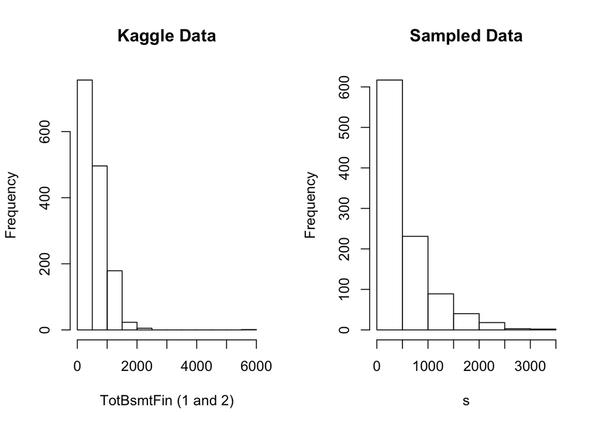

```r
s <- rexp(1000, lam)

#histogram of old and new
par(mfrow=c(1,2))
hist(train$BsmtFinSF12, main="Kaggle Data", xlab="TotBsmtFin (1 and 2)")
hist(s, main="Sampled Data")
```

The two distributions follow the same form with a lower peak in the sampling.

The CDF is $ P = 1 − e^-x$ which means that $X = log(1-P)/-\lambda$

```r
# Obtain CDF for 5% and 95% for the sample data.
cdf_5 <- log(1 - .05)/-lam
cdf_95 <- log(1 - .95)/-lam

# obtain normality 5% and 95%
#this is done using quantiles which assume IID
quantile(train$BsmtFinSF12, 0.05)
```

```
## 5%
##  0
```

```r
quantile(train$BsmtFinSF12, 0.95)
```

```
##  95%
## 1309
```

```r
#Generate Confidence Interval
#Use RMISC to calculate Confidence Interval
library(Rmisc)
CI(train$BsmtFinSF12, 0.95)
```

```
##    upper     mean    lower
## 514.6308 490.1890 465.7472
```

```r
print(cdf_5)
```

```
##     rate
## 25.14342
```

```r
print(cdf_95)
```

```
##     rate
## 1468.475
```

This means that the lower value is 466 and the upper is 515 for the Kaggle dataset. The CDF from the sample data provides a range of 26 and 1469. This means that the exponential function is NOT a good model to fit to the data. The spread of the empirical data in the exponential is encompassing nearly all the data vs the actual normal bounds for the original data.

### Modeling

#### Step 1. Split the Data.

The first step is to split the data into a training set and a test set.

```r
# Split data in reg and train
#using ntrain from the 2nd question

n <- nrow(ntrain) #1460 rows of data
shuffle_ntrain <- ntrain[sample(n), ]
train_indices <- 1:round(0.7 * n)
trainsub <- shuffle_ntrain[train_indices, ]
test_indices <- (round(0.7 * n) + 1):n
testsub <- shuffle_ntrain[test_indices, ]
testsub[is.na(testsub)] <- 0
ntrain[is.na(ntrain)] <- 0
```

#### Step 2. Create Multiple Linear Regression Model.

The next step is to create a multiple regression model. This is just an expansion of the lm() function inside r and providing more than 1 independent variable for anlaysis. In this case, the first model was generated by passing in all the numeric variables into the lm() function. Upon further inspection, the independent variables were whittled down to select only those of significance and a 2nd pass model was generated.

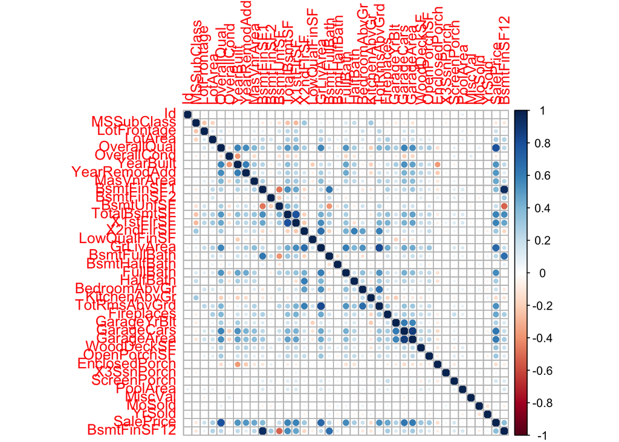

```r
#fit a linear regression model
newdatacor = cor(trainsub)
corrplot(newdatacor)
```

```r
model <- lm(SalePrice ~ ., data=trainsub)
summary(model)
```

```
##
## Call:
## lm(formula = SalePrice ~ ., data = trainsub)
##
## Residuals:
##     Min      1Q  Median      3Q     Max
## -402344  -17631   -2378   15330  212543
##
## Coefficients: (3 not defined because of singularities)
##                 Estimate Std. Error t value Pr(>|t|)
## (Intercept)    8.119e+05  1.594e+06   0.509 0.610631
## Id             7.515e-01  2.472e+00   0.304 0.761142
## MSSubClass    -1.656e+02  3.121e+01  -5.306 1.39e-07 ***
## LotFrontage   -3.409e+01  3.247e+01  -1.050 0.294037
## LotArea        5.046e-01  1.112e-01   4.536 6.45e-06 ***
## OverallQual    1.782e+04  1.367e+03  13.040  < 2e-16 ***
## OverallCond    5.727e+03  1.204e+03   4.758 2.25e-06 ***
## YearBuilt      3.598e+02  6.938e+01   5.185 2.62e-07 ***
## YearRemodAdd   9.675e+01  7.583e+01   1.276 0.202291
## MasVnrArea     3.094e+01  6.688e+00   4.626 4.23e-06 ***
## BsmtFinSF1     1.575e+01  5.010e+00   3.145 0.001713 **
## BsmtFinSF2     5.593e+00  7.962e+00   0.702 0.482600
## BsmtUnfSF      6.673e+00  4.454e+00   1.498 0.134434
## TotalBsmtSF           NA         NA      NA       NA
## X1stFlrSF      3.789e+01  6.566e+00   5.772 1.05e-08 ***
## X2ndFlrSF      3.672e+01  5.778e+00   6.355 3.17e-10 ***
## LowQualFinSF   1.376e+01  2.160e+01   0.637 0.524110
## GrLivArea             NA         NA      NA       NA
## BsmtFullBath   9.806e+03  2.872e+03   3.415 0.000664 ***
## BsmtHalfBath  -2.044e+03  4.624e+03  -0.442 0.658630
## FullBath       7.097e+03  3.172e+03   2.237 0.025480 *
## HalfBath      -1.645e+03  3.021e+03  -0.545 0.586193
## BedroomAbvGr  -1.143e+04  1.923e+03  -5.942 3.89e-09 ***
## KitchenAbvGr  -1.727e+04  5.767e+03  -2.995 0.002813 **
## TotRmsAbvGrd   8.437e+03  1.415e+03   5.965 3.41e-09 ***
## Fireplaces     2.152e+03  1.994e+03   1.079 0.280658
## GarageYrBlt   -1.246e+01  3.099e+00  -4.021 6.24e-05 ***
## GarageCars     1.525e+04  3.322e+03   4.590 4.99e-06 ***
## GarageArea     3.402e+00  1.092e+01   0.312 0.755455
## WoodDeckSF     3.757e+01  9.561e+00   3.929 9.11e-05 ***
## OpenPorchSF    1.779e+01  1.740e+01   1.022 0.306882
## EnclosedPorch  3.382e+01  1.940e+01   1.743 0.081670 .
## X3SsnPorch     1.689e+01  3.139e+01   0.538 0.590753
## ScreenPorch    8.361e+01  1.869e+01   4.474 8.59e-06 ***
## PoolArea      -1.178e+02  2.566e+01  -4.591 4.98e-06 ***
## MiscVal        3.027e-01  1.994e+00   0.152 0.879408
## MoSold         4.201e+00  3.902e+02   0.011 0.991412
## YrSold        -8.817e+02  7.938e+02  -1.111 0.266985
## BsmtFinSF12           NA         NA      NA       NA
## ---
## Signif. codes:  0 '***' 0.001 '**' 0.01 '*' 0.05 '.' 0.1 ' ' 1
##
## Residual standard error: 32900 on 986 degrees of freedom
## Multiple R-squared:  0.8309, Adjusted R-squared:  0.8249
## F-statistic: 138.4 on 35 and 986 DF,  p-value: < 2.2e-16
```

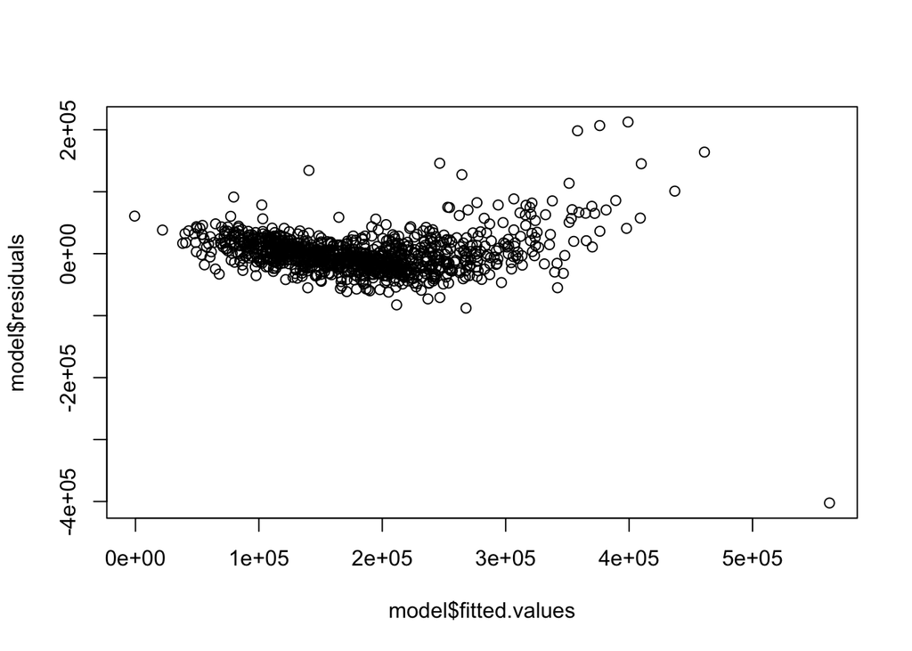

```r
plot(model$residuals ~ model$fitted.values)
```

```r
#extract variables that are significant and rerun model
sigvars <- data.frame(summary(model)$coef[summary(model)$coef[,4] <= .05, 4])
sigvars <- add_rownames(sigvars, "vars")
colist<-dplyr::pull(sigvars, vars)

idx <- match(colist, names(trainsub))
trainsub2 <- cbind(trainsub[,idx], trainsub['SalePrice'])

model2<-lm(SalePrice ~ ., data=trainsub2)

summary(model2)
```

```
##
## Call:
## lm(formula = SalePrice ~ ., data = trainsub2)
##
## Residuals:
##     Min      1Q  Median      3Q     Max
## -397793  -17285   -2394   14752  210450
##
## Coefficients:
##                Estimate Std. Error t value Pr(>|t|)
## (Intercept)  -7.465e+05  1.079e+05  -6.918 8.18e-12 ***
## MSSubClass   -1.628e+02  2.972e+01  -5.477 5.47e-08 ***
## LotArea       5.062e-01  1.085e-01   4.667 3.47e-06 ***
## OverallQual   1.881e+04  1.290e+03  14.580  < 2e-16 ***
## OverallCond   5.877e+03  1.087e+03   5.404 8.12e-08 ***
## YearBuilt     3.482e+02  5.491e+01   6.342 3.43e-10 ***
## MasVnrArea    2.940e+01  6.565e+00   4.478 8.41e-06 ***
## BsmtFinSF1    9.396e+00  3.311e+00   2.838 0.004634 **
## X1stFlrSF     4.567e+01  5.396e+00   8.464  < 2e-16 ***
## X2ndFlrSF     3.773e+01  4.847e+00   7.783 1.76e-14 ***
## BsmtFullBath  1.080e+04  2.613e+03   4.132 3.89e-05 ***
## FullBath      8.236e+03  2.897e+03   2.843 0.004560 **
## BedroomAbvGr -1.179e+04  1.870e+03  -6.306 4.30e-10 ***
## KitchenAbvGr -2.096e+04  5.492e+03  -3.816 0.000144 ***
## TotRmsAbvGrd  8.187e+03  1.365e+03   5.998 2.78e-09 ***
## GarageYrBlt  -1.319e+01  2.955e+00  -4.463 9.00e-06 ***
## GarageCars    1.636e+04  2.319e+03   7.056 3.19e-12 ***
## WoodDeckSF    3.710e+01  9.339e+00   3.973 7.61e-05 ***
## ScreenPorch   8.212e+01  1.809e+01   4.540 6.32e-06 ***
## PoolArea     -1.159e+02  2.529e+01  -4.583 5.17e-06 ***
## ---
## Signif. codes:  0 '***' 0.001 '**' 0.01 '*' 0.05 '.' 0.1 ' ' 1
##
## Residual standard error: 32840 on 1002 degrees of freedom
## Multiple R-squared:  0.8288, Adjusted R-squared:  0.8256
## F-statistic: 255.4 on 19 and 1002 DF,  p-value: < 2.2e-16
```

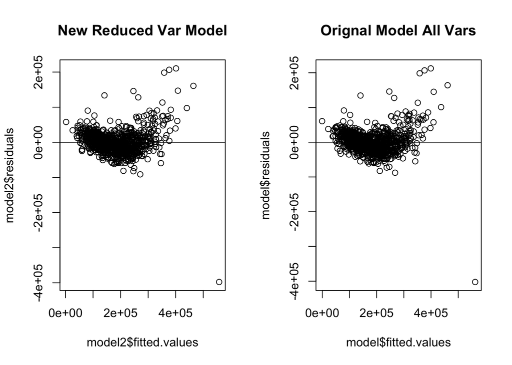

```r
par(mfrow=c(1,2))
plot(model2$residuals ~ model2$fitted.values, main="New Reduced Var Model")
abline(h = 0)
plot(model$residuals ~ model$fitted.values, main="Orignal Model All Vars")
abline(h = 0)
```

#### Step 3. Predict Values on Test Data Provided by Kaggle Competition.

The final step was to apply the linear model tot he test data provided by Kaggle for submission. In this case the training set had 1460 records and the test data had 1459 records.

```r
#predict


#select only numeric columns
test <- select_if(test, is.numeric)

test[is.na(test)] <- 0
pred2<-predict(model2,test)


#export data for Kaggle
kaggle <- as.data.frame(cbind(test$Id, pred2))
colnames(kaggle) <- c("Id", "SalePrice")

write.csv(kaggle, file = "Kaggle_Submission2.csv", quote=FALSE, row.names=FALSE)
```

After doing a second pass on my model, I was able to get predictions for the test data for the kaggle competition. In submitting my predictions, I got a score of 0.24257 for my username cspitmit03 which gave me a rank of 4786/5325 which is the 10th percentile. Note that when I added my own variables, my score actually dropped in half which means that they weren’t effective in producing better predictions.

[figure not shown]

```r
# Split data in reg and train
#using ntrain from the 2nd question
knitr::include_graphics('Submission.png')
```